# Compte Rendu TP génération de nombres aléatoires et probabilités

### Test d’ordre

Ce test n’étudie pas la suite de bits générés mais directement la suite de nombre obtenus.

Comme pour le test précédent nous nous intéressons ici aux fréquences des pvaleurs et de leur répartition par rapport à la limite à 1%.

Nous obtenons les graphiques suivants pour les différents générateurs.

#### Von Neumann

[figure not shown]

[figure not shown]

***

- Commentaire

On voit que les Pvaleurs sont soit nul soit très inférieur à 0,01. On en conclut que Von Neummann ne passe pas le test d’ordre.

#### Mersennne Twister

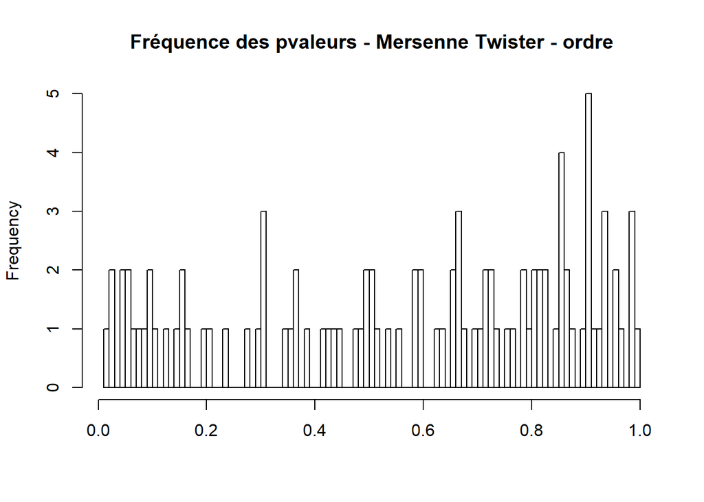

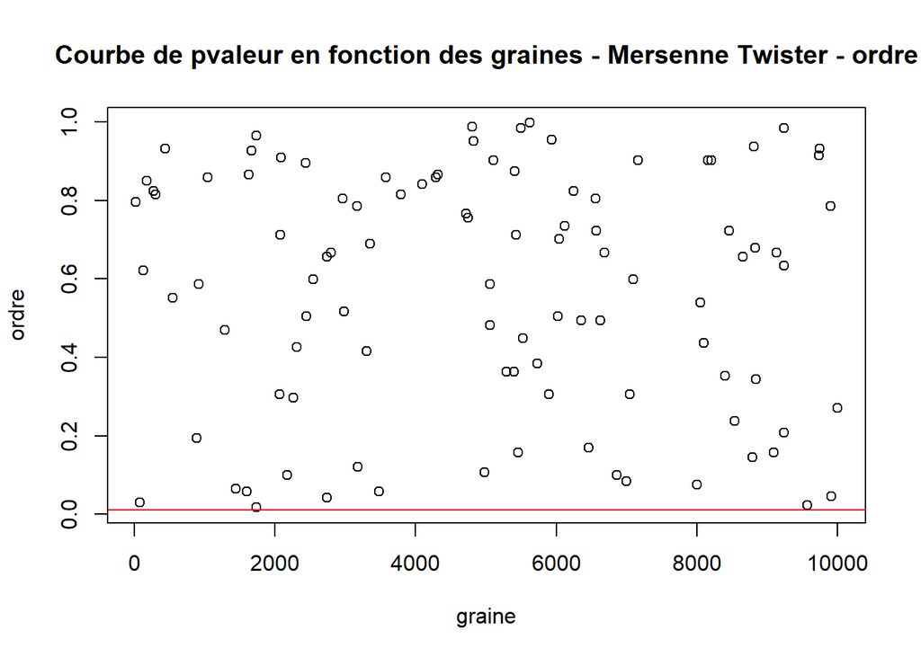

***

- Commentaire

Comme pour les autres tests, le générateur de Mersenne Twistes passe largement le test.

#### Randu

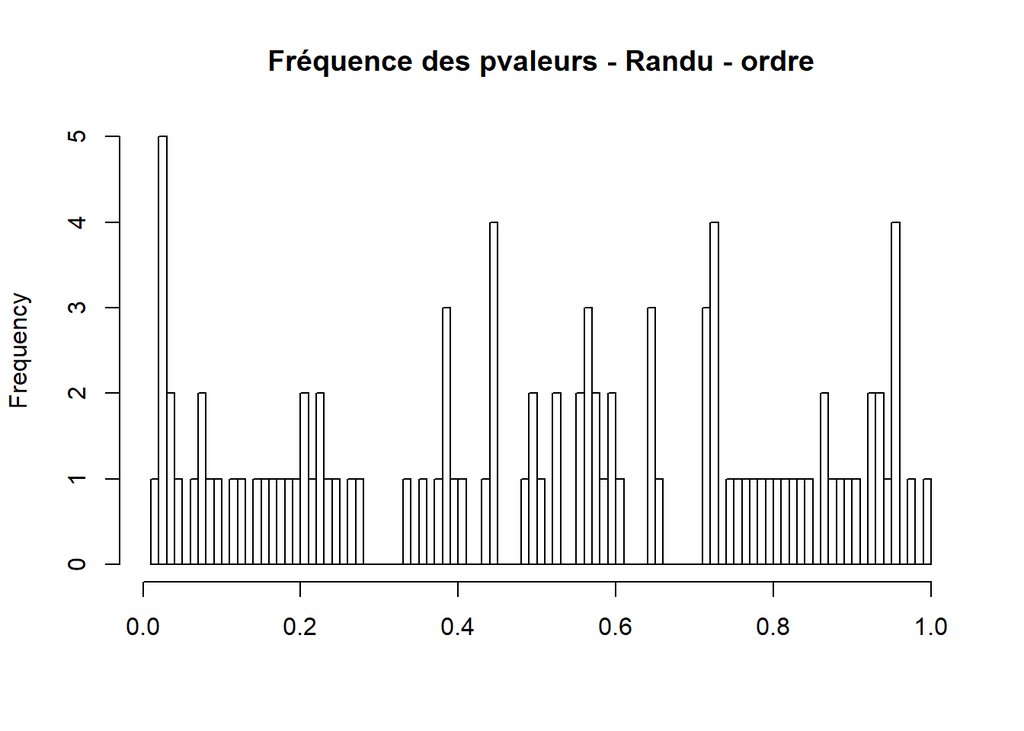

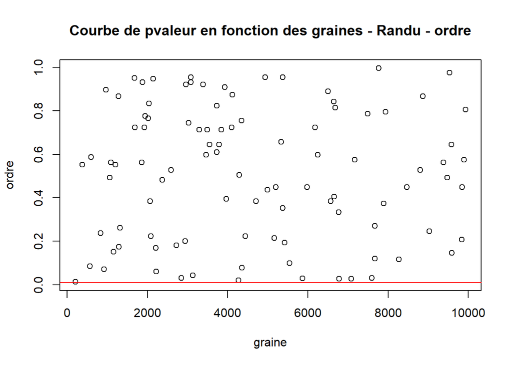

***

#### Standard Minimal

# Partie2 : Application aux files d’attente

Après avoir étudié ces différents générateurs de nombres aléatoires, nous nous intéressons dans cette partie à la modélisation d’un problème classique qui est celui des files d’attente.

## Files M/M/1

Afin de simuler un comportement type observé sur une file d’attente pendant une période D, nous avons implémenté la fonction FieMM1 qui permet de générer aléatoirement les temps d’arrivée et de départ selon le processus de poisson sur une file d’attente suivant le modèle M/M/1. Nous disposons d’un seul serveur, le temps de départ et d’arrivée suivent respectivement des lois exponentielles de paramètres $\lambda$ et $\mu$.

Une fois cette fonction implémentée, nous avons procédé à l’évaluation du nombre de personnes présentes dans la file d’attente pendant un intervalle de temps D. L’idée est d’observer à chaque arrivée ou départ aléatoire définit par la fonction FileMM1, le nombre de personnes total.

### Simulation de files d’attente

Nous présentons dans ce qui suit, l’évolution du nombre de clients dans le système pendant 12heures pour différentes valeurs des paramètres $\lambda$ et $\mu$. Il faut noter que les courbes suivantes représentent un cas particulier résultant de la génération aléatoire des dates de départ et d’arrivée, nous nous sommes basés sur plusieurs simulations afin de juger de manière pertinente le comportement des files d’attente en fonction de ces paramètres. Afin d’alléger le compte-rendu, nous nous limitons à deux simulations par paramètre.

- Simulation 1 : $\lambda$=8 et $\mu$=15

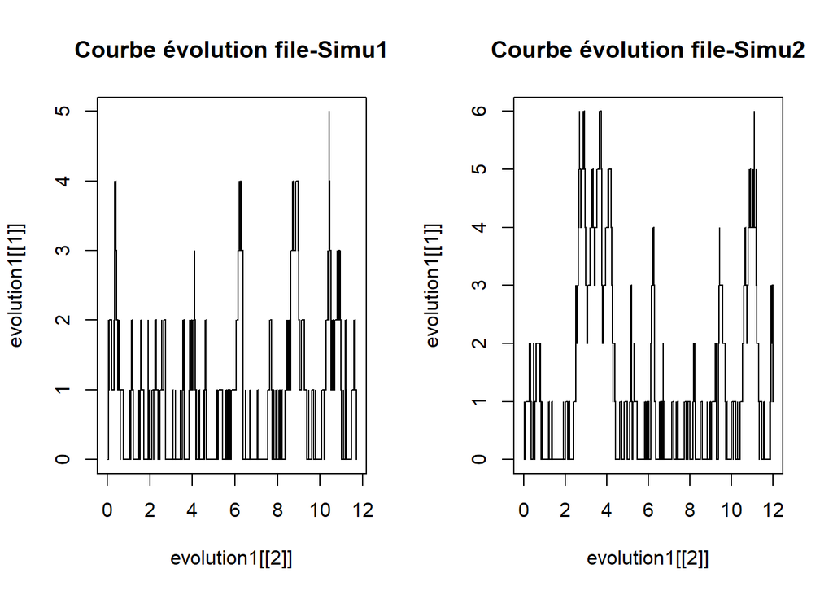

- Commentaire:

Nous remarquons que nous sommes dans le cas d’une file d’attente dans un état stable. Les entrées et sorties de clients ont l’air d’être bien maîtrisées, et nous ne remarquons pas de potentielle saturation. En effet, nous sommes dans le cas $\mu$ > $\lambda$ et donc un rapport $\alpha=\lambda / \mu$ -témoignant du traffic sur le serveur- inférieur à 1, le système a atteint ainsi un régime stationnaire. Un tel état se caractérise par une forte stabilité. Le service semble être très satisfaisant, la file se retrouve des fois vide et ne dépasse pas 5 à 6 personnes comme affluence maximale. Un client arrivant sur le serveur est tout de suite servi, on observe cela très fréquemment tout au long des 12 heures d’étude. Cela est modélisé par les rectangles qu’on rencontre fréquemment sur la courbe de hauteur =1 modélisant l’arrivée et le départ d’une seule personne. Pour des taux d’affluence maximale le système arrive très rapidement à se restabiliser autour d’un taux moins important. Les fluctuations observées sont dues au caractère aléatoire d’arrivée des clients qui restent tout de même très difficile à maîtriser malgré la qualité du service et la stabilité globale du système. Cependant ces fluctuations restent très minimes et ne nous empêchent pas d’affirmer que ce modèle présente une excellente stabilité. Ceci est tout à fait normal comme on a un service de très haute qualité comparée aux nombres moyens de clients arrivant sur la file d’attente.

- Simulation 2 : $\lambda$=14 et $\mu$=15

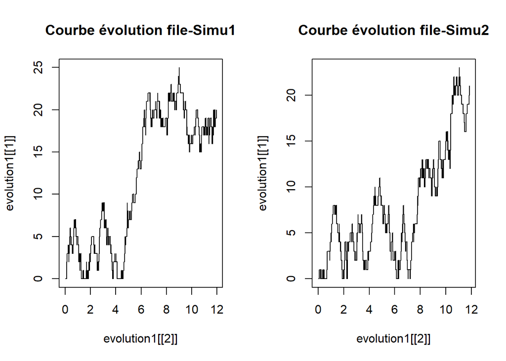

- Commentaire

On voit que pour un $\alpha$ très proche de 1, contrairement à l’exemple précédent. Nous avons beaucoup de mal à prédire le comportement de la courbe. Le modèle est beaucoup plus soumis à l’aléatoire. Le nombre de clients en attente peut monter très haut sur une durée très longue et redescendre abruptement dans certains cas. Mais on peut aussi avoir un cas ou le nombre de clients augmente et descend très rapidement sur des petits intervalles de temps. Ceci est dû au fait qu’on soit à la limite séparant la stabilité de la saturation du système.

- Simulation 3 : $\lambda$ = 15 et $\mu$ = 15

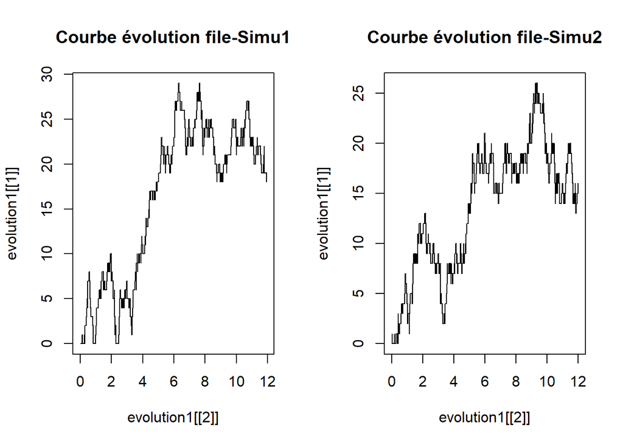

- Commentaire

On a un comportement très similaire que le graphique précédent. Ici $alpha$ est égal à 1, on a donc le même comportement imprédictible que précédemment.

- Simulation 4 : $\lambda$ = 20 et $\mu$ = 15

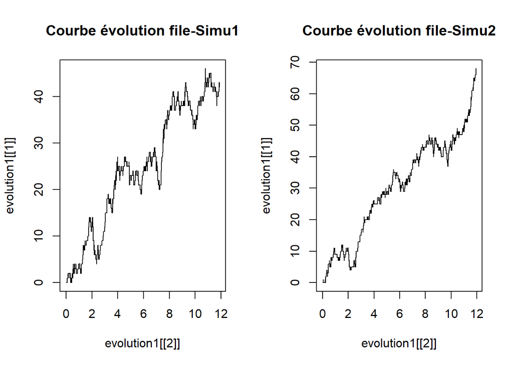

- Commentaire

On a ici un $\alpha$ supérieur à 0. C’est à dire qu’on plus de personnes arrivant dans la file que de personne partant de la file. Le nombre de personnes croît continuellement, on a donc ici une courbe prédictible qui va systématiquement diverger, on atteint la saturation assez rapidement.

### Vérification de la formule de Little

Nous nous intéressons dans cette partie à l’étude de régime stationnaire. Nous étudierons ainsi différentes simulations dont l’intensité du trafic est inférieur à 1 afin de garantir le caractère stable de la simulation et pouvoir appliquer les différentes approximations. Il s’agira ainsi d’estimer le nombre moyen de clients dans le système ainsi que le temps de présence d’un client dans le système. Le nombre moyen de clients peut être obtenu en calculant la moyenne du nombre de clients sur l’intervalle de temps étudié. Cette moyenne peut être obtenue en calculant la somme totale des clients représentée par la surface sous la courbe de simulation puis en divisant par l’intervalle d’étude. Comme nous ne disposons pas de la fonction décrivant l’évolution du nombre de clients pendant le temps, nous sommes incapable de calculer cette surface grâce à une intégrale, cependant nous arrivons à approximer cette surface grâce à une somme de Riemann. Nous considérons que nos intervalles de temps sont assez fin afin de garantir un minimum de justesse et de finesse à nos calculs. Le temps de présence moyen d’un client est facilement calculable en sommant les temps d’attente élémentaires et en moyennant cette somme on arrive facilement à estimer ce temps. Une fois ces nombres déterminés, nous vérifierons si ces valeurs s’approchent des valeurs théoriques en comparant le nombre de clients moyen à la valeur $\alpha/\alpha-1$ et en vérifiant la validité de la formule de Little.

Un exemple de simulation étant généré aléatoirement ne suffit pas pour conclure, nous calculerons ainsi ces différents taux pour plusieurs simulations de $\alpha$ respectant l’hypothèse de système stationnaire. Nous réaliserons nos calculs pour des intervalles de temps plus larges afin de minimiser les potentielles erreurs.

Nous présentons notre étude dans le tableau suivant : nous avons réalisé 100 simulations différentes pour chaque valeur de $\lambda$ afin d’obtenir une meilleure précision en minimisant les erreurs éventuelles dues à l’aléatoire.

| $\lambda$ | nbClient moyen | TmpPrésence | TmpLittle | EcartThéorique |
| --- | --- | --- | --- | --- |
| 8 | 1.45 | 0.14 | 0.18 | 0.04 |
| 14 | 6.53 | 0.45 | 0.47 | 0.03 |

Ainsi pour $\alpha=0.53$ nous obtenons un nombre de clients moyen de 1.45 ce qui est tout à fait cohérent avec la courbe d’évolution où l’on observait 1 client très fréquemment. Pour les deux valeurs de $\lambda$, nous avons calculé le temps obtenu selon la formule de Little, on remarque un écart théorique très faible plus important dans le premier cas. On en conclut qu’on vérifie bien la formule de Little pour les deux valeurs de $\lambda$. Ceci peut nous amener à confirmer encore une fois le régime stationnaire atteint par la file d’attente pour $\lambda=8$, cependant on peut rien conclure de plus pour $\lambda=14$ malgré qu’elle vérifie la formule de Little. En effet, sa courbe d’évolution représente un caractère pas tout à fait stationnaire comme nous l’avons précisé auparavant.

| nbHeures | nbClient moyen | TmpPrésence | TmpLittle | EcartThéorique |
| --- | --- | --- | --- | --- |
| 24 | 1.48 | 0.15 | 0.19 | 0.04 |
| 70 | 1.44 | 0.14 | 0.18 | 0.04 |
| 300 | 1.44 | 0.14 | 0.18 | 0.04 |

On remarque qu’on gagne faiblement en précision, on peut ainsi se restreindre à un nombre raisonnable d’heures afin d’affirmer nos observations.

Finalement on pourrait explorer d’autres valeurs de $\lambda$ afin d’évaluer à quel point on se rapproche de la formule de Little pour différentes intensités de trafic.

| $\lambda$ | nbClient moyen | TmpPrésence | TmpLittle | EcartThéorique |
| --- | --- | --- | --- | --- |
| 3 | 0.92 | 0.08 | 0.31 | 0.22 |
| 5 | 0.98 | 0.1 | 0.2 | 0.1 |
| 7 | 1.26 | 0.13 | 0.18 | 0.06 |
| 11 | 2.48 | 0.21 | 0.23 | 0.02 |

Nous remarquons ainsi que plus $\lambda$ est grand plus on se rapproche de la formule de Little. Un juste milieu est donc à trouver entre la valeur de lambda $\lambda$, le nombre d’heures d’observation afin de trouver le système le plsu stationnaire possible.